# Task: Multidimensional scaling

Liam Cook

2025-03-11

## Iris

The data frame `iris` is similar to the penguins data we have been using, except it is about iris plants.

Here is a pairs plot of four quantitative variables from this dataset. The diagonal shows the density of each variable. Below the diagonal is a scatter plot of pairs of varibles. Above the diagonal is the Pearson correlation between pairs of variables. Colour is used to distinguish the three species.

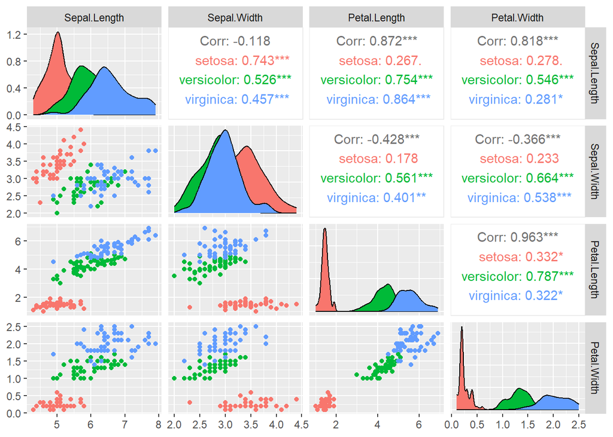

```r
iris |> ggpairs(aes(color=Species), columns=1:4, progress=FALSE)
```

## PCA

Use `prcomp` to create a PCA of the four quantitative variables in `iris`.

```r
data(iris)
pca_result <- prcomp(iris[, 1:4], center = TRUE, scale. = TRUE)
summary(pca_result)
```

```
## Importance of components:
##                           PC1    PC2     PC3     PC4
## Standard deviation     1.7084 0.9560 0.38309 0.14393
## Proportion of Variance 0.7296 0.2285 0.03669 0.00518
## Cumulative Proportion  0.7296 0.9581 0.99482 1.00000
```

Use `autoplot` to create a “biplot” showing the data projected onto the first two principal components. Colour the points according to the species. (Note you have to spell colour with a “u” in this command, and you need to put the variable name ‘Species’ in quotation marks; this is different from the way most functions we’ve been using work.) Show the “loading” vectors with their labels.

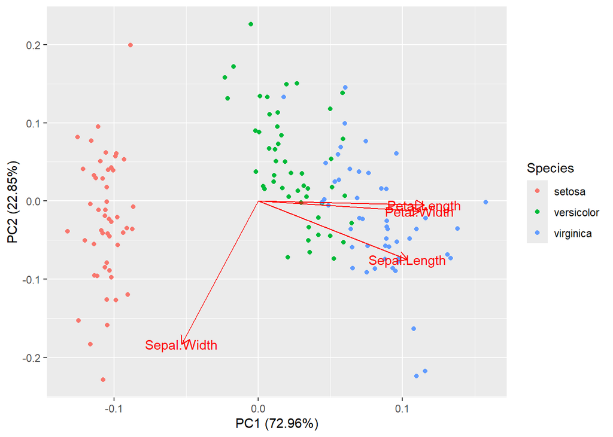

```r
autoplot(pca_result, data = iris, colour = "Species", loadings = TRUE, loadings.label = TRUE)
```

Use `augment` and `ggplot` to make your own customized biplot. You don’t need to include the loading arrows, but you can if you like.

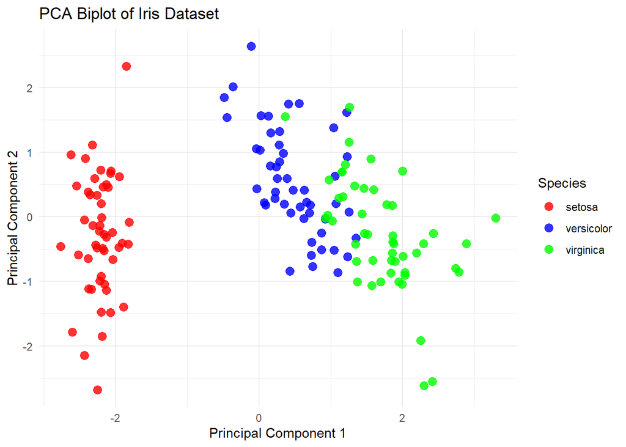

```r
pca_augmented <- augment(pca_result, data = iris)

ggplot(pca_augmented, aes(.fittedPC1, .fittedPC2, colour = Species)) +
  geom_point(size = 3, alpha = 0.8) +
  labs(title = "PCA Biplot of Iris Dataset",
       x = "Principal Component 1",
       y = "Principal Component 2") +
  theme_minimal() +
  scale_color_manual(values = c("red", "blue", "green"))
```

## MDS

First we will use the function `dist` to compute the distance between each plant (row) in the `iris` dataset.

```r
dist1 <- dist(iris |> select(-Species) |> scale() )
```

Use `metaMDS` from the `vegan` package to perform multidimensional scaling on the iris data using this distance matrix.

```r
dist1 <- dist(iris |> select(-Species) |> scale())

mds_result <- metaMDS(dist1, k = 2, trymax = 100)
```

```
## *** Best solution repeated 8 times
```

```r
mds_result
```

```
##
## Call:
## metaMDS(comm = dist1, k = 2, trymax = 100)
##
## global Multidimensional Scaling using monoMDS
##
## Data:     dist1
## Distance: euclidean
##
## Dimensions: 2
## Stress:     0.04212487
## Stress type 1, weak ties
## Best solution was repeated 8 times in 20 tries
## The best solution was from try 7 (random start)
## Scaling: centring, PC rotation
## Species: scores missing
```

Use `ordiplot` to show the points as separated into the two dimensional ordination space.

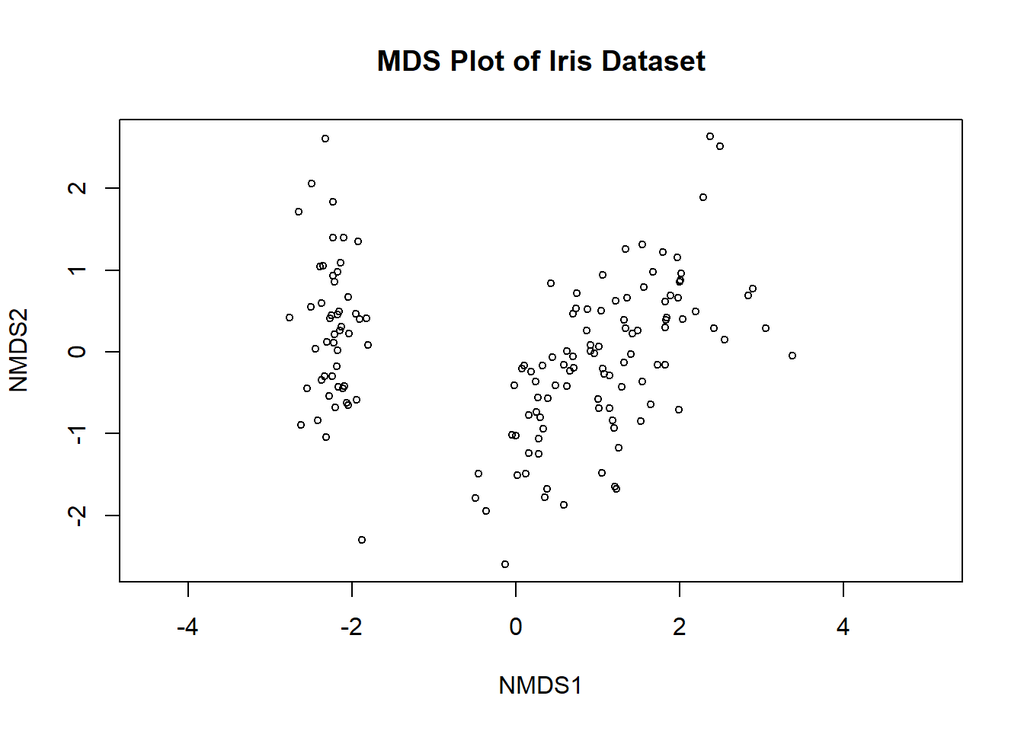

```r
ordiplot(mds_result, type = "points", display = "sites", main = "MDS Plot of Iris Dataset")
```

If the result of your MDS is stored in a variable called `mds1` you can get the MDS coordinates of each plant using `mds1$points` (change `mds1` to the name of the object you stored the MDS analysis in.) Below I also use the `as_tibble` function to convert the matrix to a tibble in preparation for our next step.

```r
mds_result$points |> as_tibble()
```

```
## # A tibble: 150 × 2
##     MDS1    MDS2
##    <dbl>   <dbl>
##  1 -2.25  0.445
##  2 -2.07 -0.628
##  3 -2.34 -0.302
##  4 -2.28 -0.539
##  5 -2.38  0.592
##  6 -2.10  1.39
##  7 -2.45  0.0407
##  8 -2.21  0.217
##  9 -2.32 -1.04
## 10 -2.17 -0.430
## # ℹ 140 more rows
```

Use `bind_cols` to combine these points with the original `iris` dataset. Make a scatter plot using the MDS coordinates and colour the points using the Species variable.

```r
bind_cols(iris, mds_result$points |> as_tibble())
```

[output not shown]

[output cut: 287 more lines]

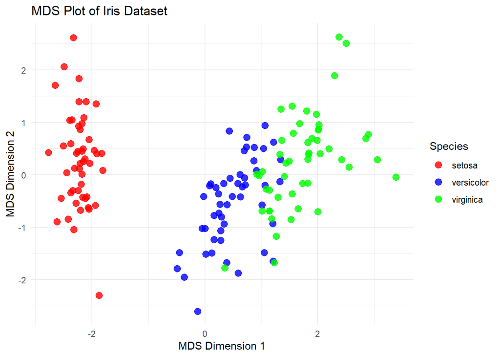

```r
mds_data <- bind_cols(iris, as_tibble(mds_result$points))
colnames(mds_data)[6:7] <- c("MDS1", "MDS2")
ggplot(mds_data, aes(x = MDS1, y = MDS2, colour = Species)) +
  geom_point(size = 3, alpha = 0.8) +
  labs(title = "MDS Plot of Iris Dataset",
       x = "MDS Dimension 1",
       y = "MDS Dimension 2") +
  theme_minimal() +
  scale_color_manual(values = c("red", "blue", "green"))
```

Make a scatterplot using any two of the original quantitative from `iris`.

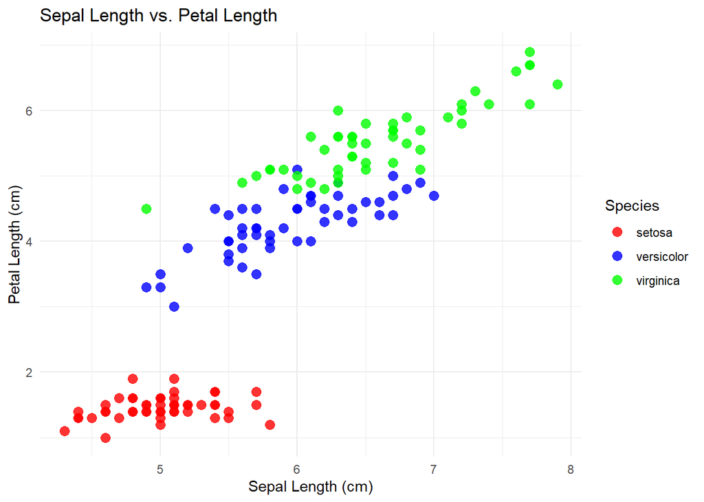

```r
library(ggplot2)

ggplot(iris, aes(x = Sepal.Length, y = Petal.Length, colour = Species)) +
  geom_point(size = 3, alpha = 0.8) +
  labs(title = "Sepal Length vs. Petal Length",
       x = "Sepal Length (cm)",
       y = "Petal Length (cm)") +
  theme_minimal() +
  scale_color_manual(values = c("red", "blue", "green"))
```

**Do the species form three separate clusters in your plot using the original data? Are the observations separated in the plane according to the species name in the MDS plot?**

*The species mostly form three clusters in the plot, Setosa clearly is a bit separate while Versicolor and Virginica overlap. The MDS plot has a similar pattern (Setosa stays distinct), but there’s still some overlap between Versicolor and Virginica. Overall, both plots show a reasonable separation.*